# STAT510 Lesson 6 Application

Ada Lazuli

2026-06-28

## Front Matter

```r
set.seed(101011)
remove(list = ls())
library(astsa)
library(ggplot2)
library(reactable)
library(tidyverse)
library(dplyr)
```

## Question 1

#### Part A

> Roughly, at what frequency is the dominant peak?

The frequency is roughly 0.085

#### Part B

> The period of a cycle is the reciprocal of the frequency. About what is the period for the frequency at which the dominant peak occurs? (Keep in mind that this is monthly data.)

The period of the cycle is:

$$\frac{1}{0.085} = 11.765$$

Given that this is monthly data and roughly 11.765 samples make one cycle, it is likely that the period is actually 12 and represents one year.

## Question 2

> Use the dataset “speech.dat” from the Lesson 6 Module. The data are described in Example 1.3 on page 4 of the textbook. The series is a sample of recorded speech of the phrase aaa…hhh, sampled for 0.1020 seconds at the rate of 10,000 points per second. Thus there are n = 1020 data values. The authors don’t say what exactly is the response variable, but a likely possibility for the response is a measure of the audio frequency of the sound. (Maybe they held out from saying that to avoid confusion with the frequency of a cosine wave.)

> The data can be read as `x = scan("speech.dat")` once the data file is in place on your computer.

> There’s no obvious trend seen in Figure 1.3 on page 4, but it never hurts to detrend before looking at a periodogram. At worst, detrending does nothing. Detrend in R by doing a linear regression on the time index. The detrended values are the residuals from this regression. The sequence of commands might be something like

> ```r
> t = 1:1020
> regr = lm(x~t)
> y = residuals(regr)
> ```

> In the above code, y would be the detrended series, the residuals from a linear regression. Plot the periodogram of the detrended series. Give the plot and describe the pattern of peaks as they relate to frequency (the horizontal axis).

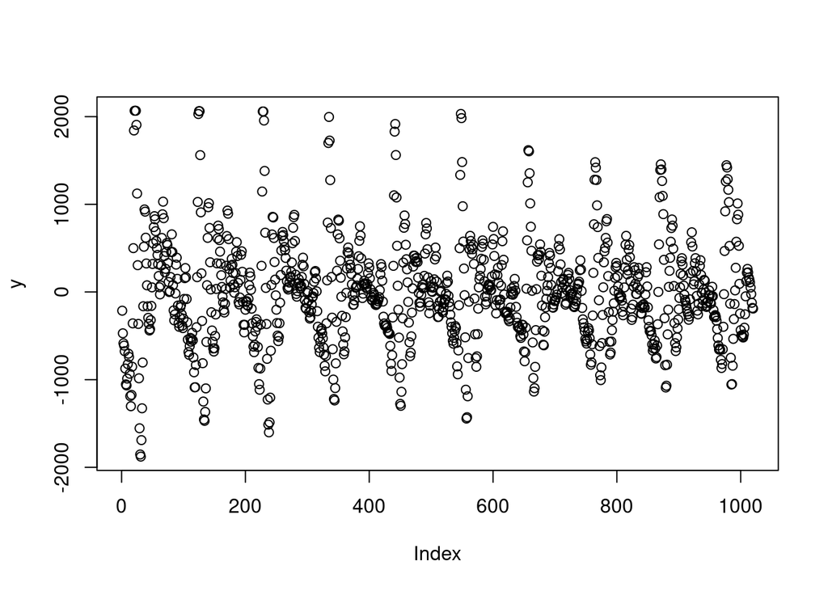

```r
x <- scan("../sample_data/speech.dat")
t <- 1:length(x)
regr <- lm(x ~ t)
y <- residuals(regr)
plot(y)
```

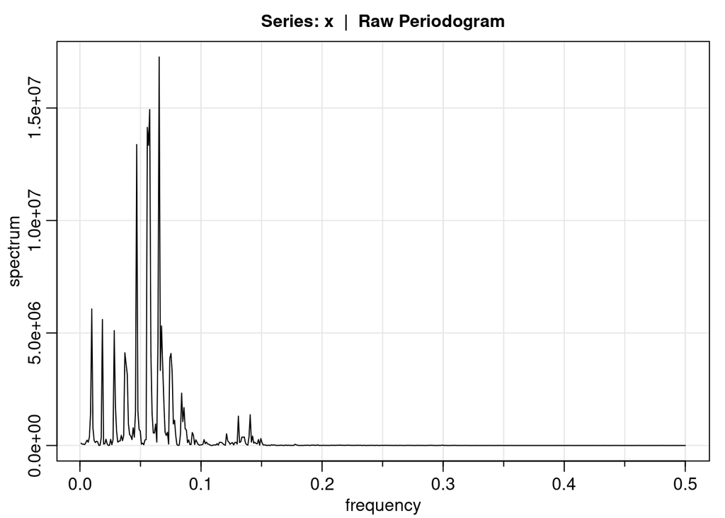

```r
mvspec(x, log="no")
```

The periodogram shows several frequencies between approximately 0.01 to 0.08, with the strongest ones being closer to 0.06. There are almost like two “levels” in the periodogram, with the lower ones near 0.01 and the larger ones centered on 0.06. This seems to capture the very quick cycles at the beginnng of the vocalizations and the longer cycles in the middle to end of the cycles.

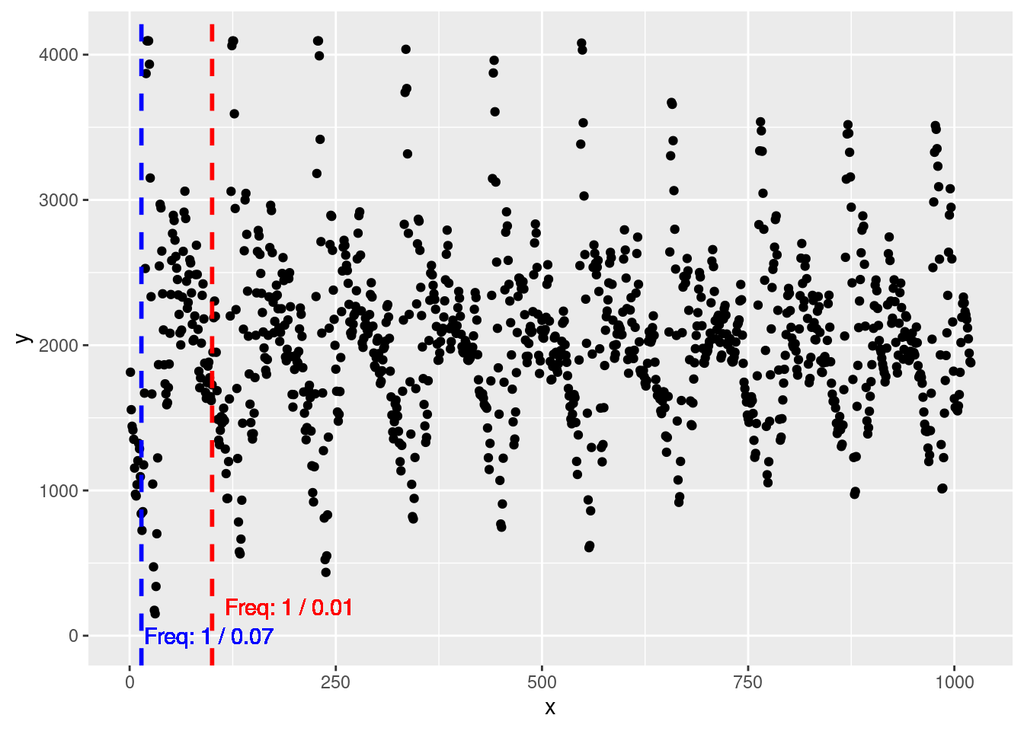

```r
df <- data.frame(y = x, x = 1:length(x))
ggplot(df, aes(x = x, y = y)) +
  geom_point() +
  geom_vline(xintercept = 1/.07, color = "blue", linetype = "dashed", size = 1) +
  geom_text(aes(x = 1/0.7, y = 0, label = "Freq: 1 / 0.07"),
            color = "blue", hjust = -0.1) +
  geom_vline(xintercept = 1/.01, color = "red", linetype = "dashed", size = 1) +
  geom_text(aes(x = 1/0.01, y = 200, label = "Freq: 1 / 0.01"),
            color = "red", hjust = -0.1)
```

After plotting the two groupings of frequencies, it seems that the periodogram picked up on the two cycles with periods of approximately 14 and $\approx$ 100.

## Question 3

> See Lesson 12.1 for guidance.

#### Part A

> What are the weighting coefficients for a Daniell kernel with m = 3?

```r
kernel("daniell", m= 3)
```

```
## Daniell(3)
## coef[-3] = 0.1429
## coef[-2] = 0.1429
## coef[-1] = 0.1429
## coef[ 0] = 0.1429
## coef[ 1] = 0.1429
## coef[ 2] = 0.1429
## coef[ 3] = 0.1429
```

The weighting coefficient is 0.1428571 for time stamps $x_{t-3}$ to $x_{t + 3}$

#### Part B

> What are the weighting coefficients for a Daniell kernel that is convoluted (repeated) with m = 3 in both smoothings?

The weighting coefficients are:

```r
kernel("daniell", c(3,3))
```

```
## Daniell(3,3)
## coef[-6] = 0.02041
## coef[-5] = 0.04082
## coef[-4] = 0.06122
## coef[-3] = 0.08163
## coef[-2] = 0.10204
## coef[-1] = 0.12245
## coef[ 0] = 0.14286
## coef[ 1] = 0.12245
## coef[ 2] = 0.10204
## coef[ 3] = 0.08163
## coef[ 4] = 0.06122
## coef[ 5] = 0.04082
## coef[ 6] = 0.02041
```

## Question 4

> Use the dataset “l12sim.dat” from the Lesson 6 Module. The data are n = 100 values simulated from an AR(2) model (with no trend).

```r
x <- scan("../sample_data/l12sim.dat")
```

#### Part A

> Use the mvspec command to determine the raw periodogram. Give the plot as the answer to this part.

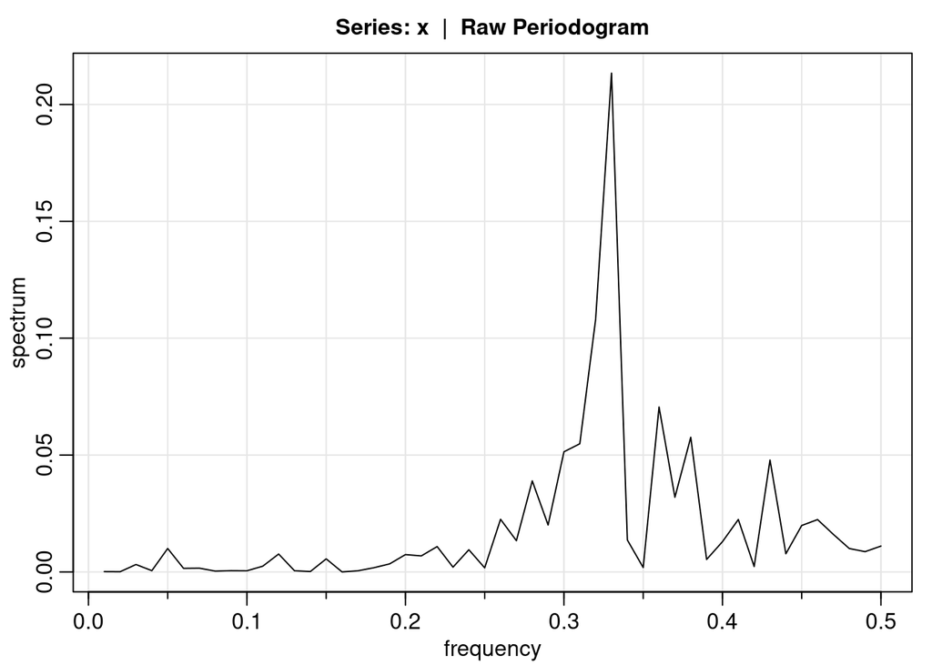

```r
mvspec(x, log="no")
```

#### Part B

> Smooth the periodogram using a Daniell kernel with m = 2. Give the plot as the answer to this part.

```r
k <- kernel("daniell", 2)
mvspec(x, k, log="no")
```

```
## Bandwidth: 0.05 | Degrees of Freedom: 10 | split taper: 0%
```

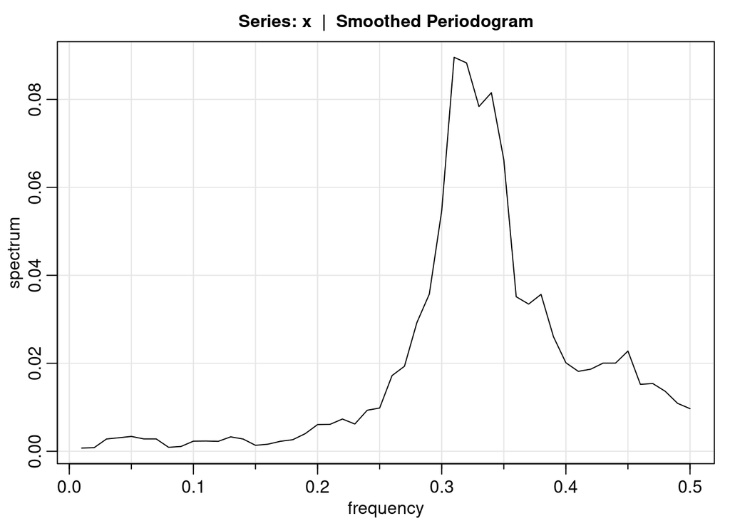

#### Part C

> Smooth the periodogram using a Daniell kernel with m = 3. Give the plot as the answer to this part.

```r
k <- kernel("daniell", 3)
mvspec(x, k, log="no")
```

```
## Bandwidth: 0.07 | Degrees of Freedom: 14 | split taper: 0%
```

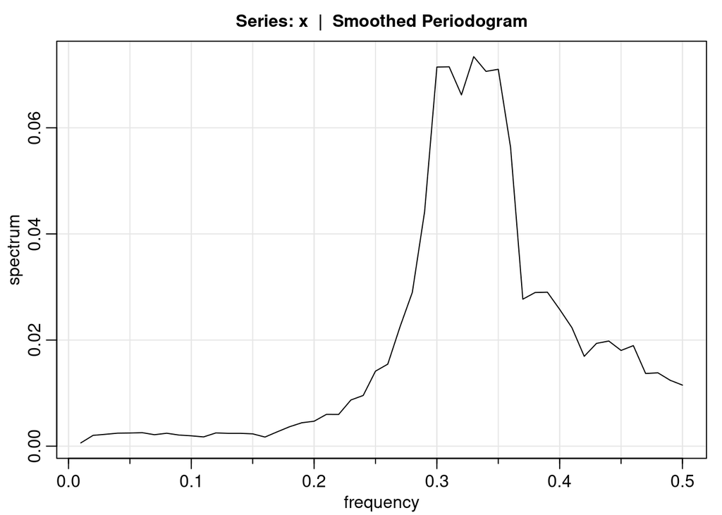

#### Part D

> Smooth the periodogram using two passes of a Daniell kernel with m = 3 for each pass. Give the plot as the answer to this part.

```r
k <- kernel("daniell", c(3,3))
specvalues <- mvspec(x, k, log="no")
```

```
## Bandwidth: 0.104 | Degrees of Freedom: 20.79 | split taper: 0%
```

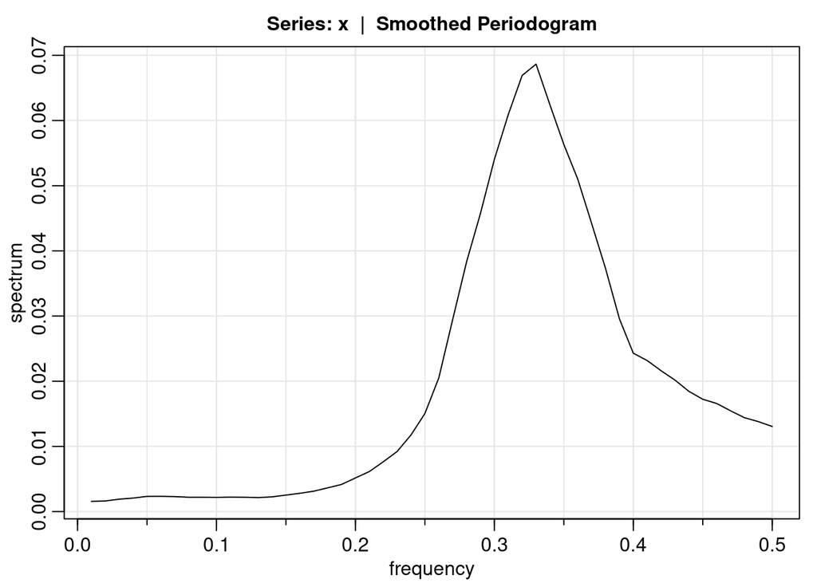

#### Part E

> Using the smoothed periodogram in part D, identify the approximate frequency at which the maximum spectral density occurs. This can be estimated visually, but also can be done be assigning a name to the mvspec result by doing something like `specvalues = mvspec(……)` After carrying out this command, use the command specvalues and examine the results.

> What is the frequency at which the peak occurs? What is the period associated with this frequency? Recall that period = 1/frequency.

```r
freq <- specvalues$freq[which.max(specvalues$spec)]
freq
```

```
## [1] 0.33
```

The frequency is approximately 0.33 and the period is:

$$\frac{1}{0.33} \approx 3$$

#### Part F

> Use spec.ar to determine the parametric estimate of the spectral density. Give the plot of the estimated spectral density. What AR order was used to create this estimate?

```r
specvalues <- spec.ar(x, log="no")
```

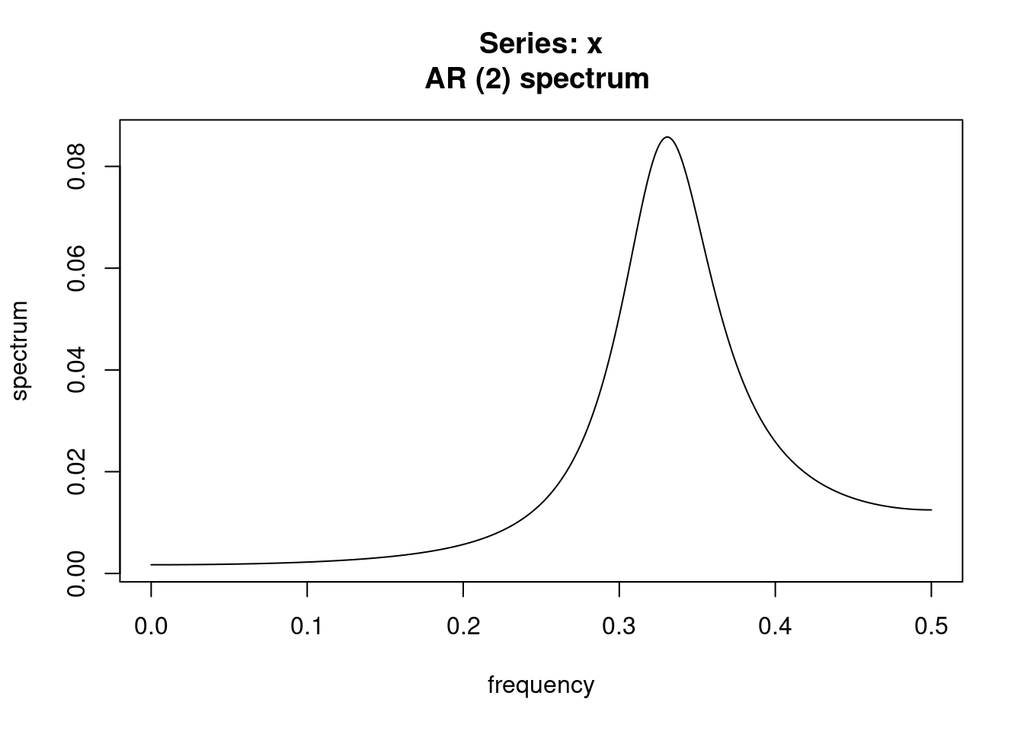

An **AR(2) model** was used to create the estimate.

#### Part G

> Using the parametric estimate of the spectral density, estimate the approximate frequency at which the maximum spectral density occurs.

```r
freq <- specvalues$freq[which.max(specvalues$spec)]
freq
```

```
## [1] 0.3306613
```

The frequency is approximately 0.3306613 and the period is:

$$\frac{1}{0.3306613} \approx 3$$

#### Part H

> (Review of ARIMA work) Determine the acf and pacf of the data series. Give the graphs and write a brief discussion of what model is suggested. You might use load the astsa library and then acf2(..)

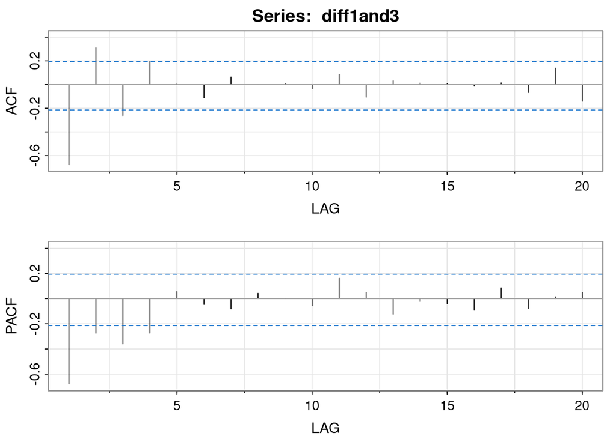

```
##       [,1]  [,2]  [,3]  [,4] [,5]  [,6]  [,7] [,8] [,9] [,10] [,11] [,12] [,13]
## ACF  -0.68  0.31 -0.26  0.19 0.00 -0.11  0.06 0.00 0.01 -0.03  0.09 -0.11  0.03
## PACF -0.68 -0.28 -0.36 -0.27 0.06 -0.05 -0.08 0.04 0.00 -0.06  0.16  0.05 -0.12
##      [,14] [,15] [,16] [,17] [,18] [,19] [,20]
## ACF   0.01  0.01 -0.01  0.01 -0.07  0.14 -0.14
## PACF -0.02 -0.04 -0.09  0.09 -0.08  0.01  0.05
```

```r
diff1 <- diff(x,1)
diff1and3 <- diff(diff1,3)
acf2(diff1and3)
```

Based on the differencing used to stabilize the plot, $d=1$ and $D = 1$. Additionally, $S = 3$ based on the previous work in the periodograms.

The spike at lag 3 in the ACF decays quickly while the spike at lag 3 in the PACF decays slower, suggesting the seasonal components are $Q = 1$ and $P = 0$.

At lags 1 and 2, the ACF a significant drop off lag 1 and continues to decay. While the PACF has drop off after lag 1, but seems to continue through lags 2 - 4. So, $q = 1$ and $p = 0$

$$\begin{aligned}
&ARIMA(p,d,q) \times (P,D,Q)_S \\
&ARIMA(0,1,1) \times (0,1,1)_3 \\
\end{aligned}$$

#### Part I

> Use the sarima command to examine whether an AR(2) is a suitable model for these data.

```
## <><><><><><><><><><><><><><>
##
## Coefficients:
##       Estimate     SE   t.value p.value
## ar1    -0.7589 0.0776   -9.7781       0
## ar2    -0.6330 0.0768   -8.2425       0
## xmean  -1.8854 0.0040 -471.7830       0
##
## sigma^2 estimated as 0.008976052 on 97 degrees of freedom
##
## AIC = -1.782644  AICc = -1.780144  BIC = -1.678438
##
```

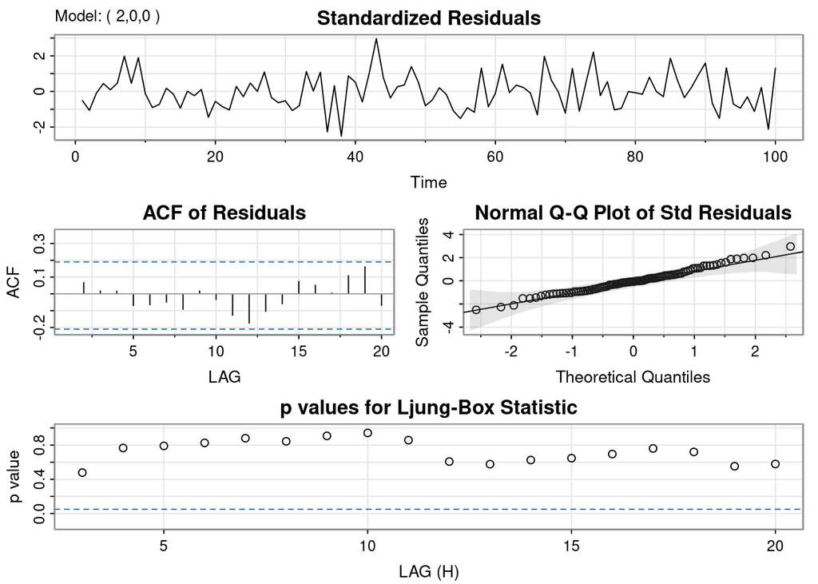

```r
sarima(x, 2, 0, 0)
```

Based on the diagnostic plots, an AR(2) models seems suitable. The ACF does not depict any significant spikes, the residuals follow a normal distribution based on the QQ-Plot, and all of the p-values in the Ljung-Box statistic plot are well above the threshold of $0.05$

## Question 5

> In R, use the command

> ```r
>  x = rnorm(250,0,1)
> ```

> This will generate a series of 250 random values from a normal distribution with mean 0 and variance 1. In other words, we’ve generated a white noise series.

> Use spec.ar to determine a parametric estimate of the spectral density for the simulated data.

> Give the graph and write a (very) brief description of its appearance.

```r
x <- rnorm(250,0,1)
specvalues <- spec.ar(x, log="no")
```

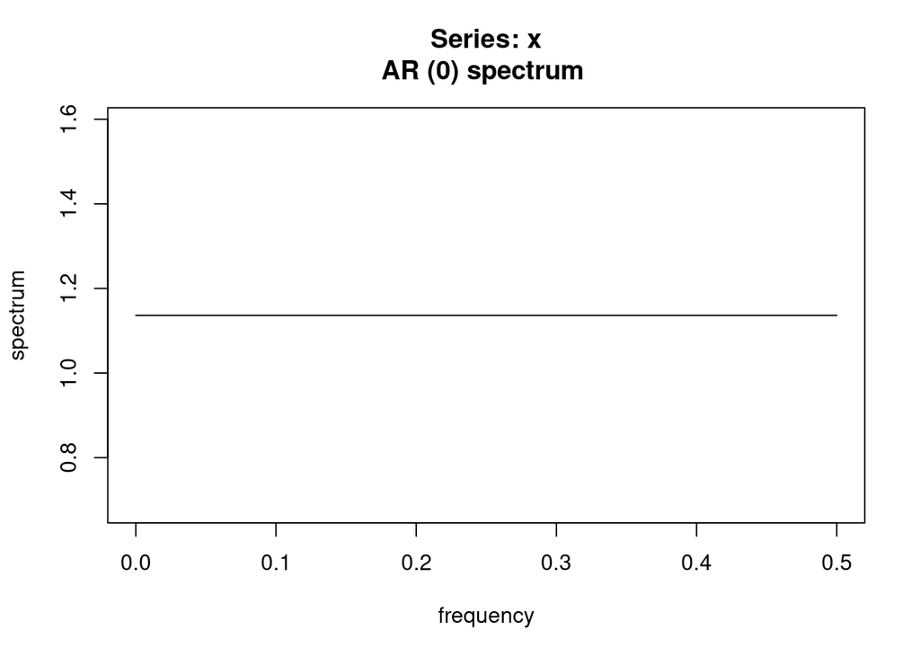

The plot depicts a straight line, indicating that are no frequencies that stand out in the data. Considering the data is completely random, it is reasonable that there are no cyclic elements in the data.

## Question 6

> Use the dataset tempm.dat in the Lesson 6 Module. It gives n = 400 weekly values of the average temperature in a city. Determine a nonparametric estimate of the spectral density of the series. Give the graph, describe what smoothing you used and describe the location of the peak density.

```r
x <- scan("../sample_data/tempm.dat")
```

Starting with the raw periodogram

```r
specvalues <- mvspec(x, log="no")
```

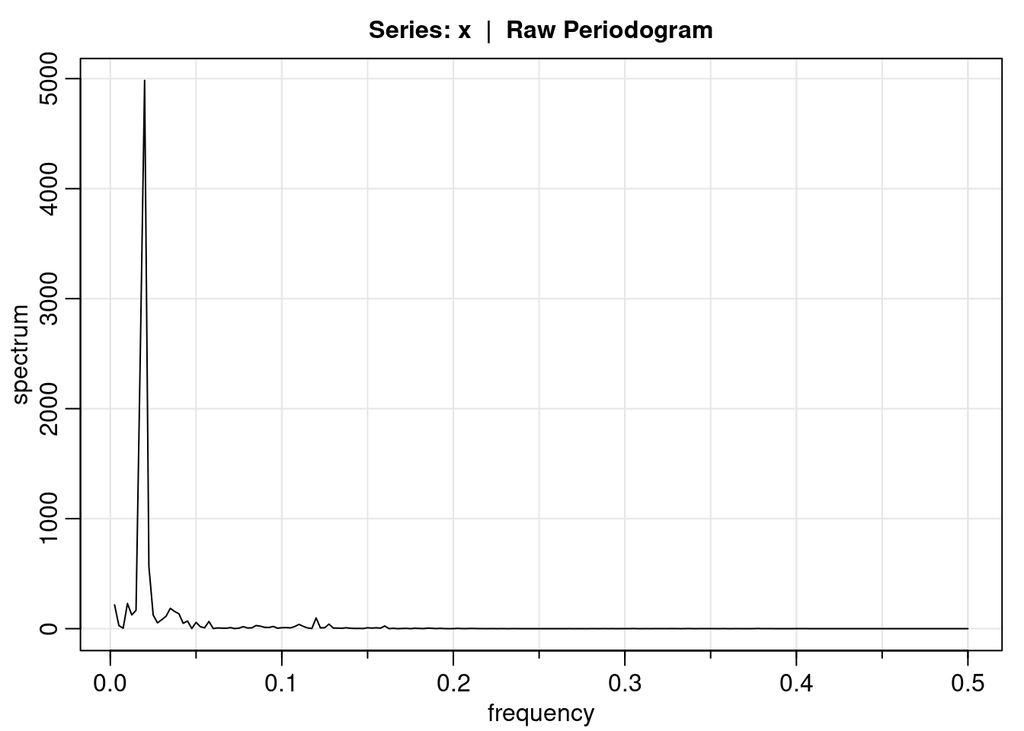

```r
freq <- specvalues$freq[which.max(specvalues$spec)]
freq
```

```
## [1] 0.02
```

It looks like frequency is 0.02.

Taking a second look with a non-parametric convoluted daniell kernel with $m = 3$:

```r
k <- kernel("daniell", c(3,3))
specvalues <- mvspec(x,k, log="no")
```

```
## Bandwidth: 0.026 | Degrees of Freedom: 20.79 | split taper: 0%
```

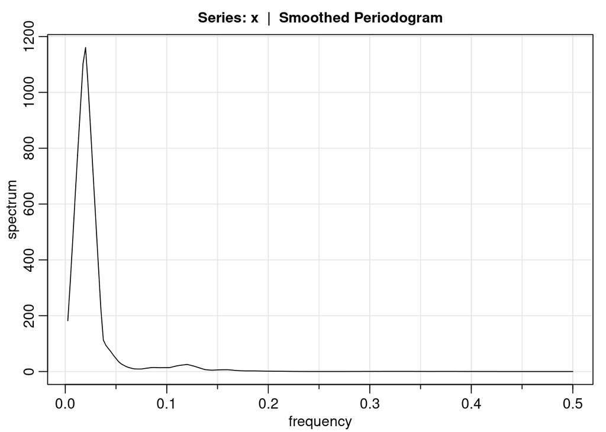

```r
freq <- specvalues$freq[which.max(specvalues$spec)]
freq
```

```
## [1] 0.02
```

After smoothing, it looks like the frequency is still 0.02.

Lastly, exploring with a parametric approach for fun:

```r
specvalues <- spec.ar(x, log="no")
```

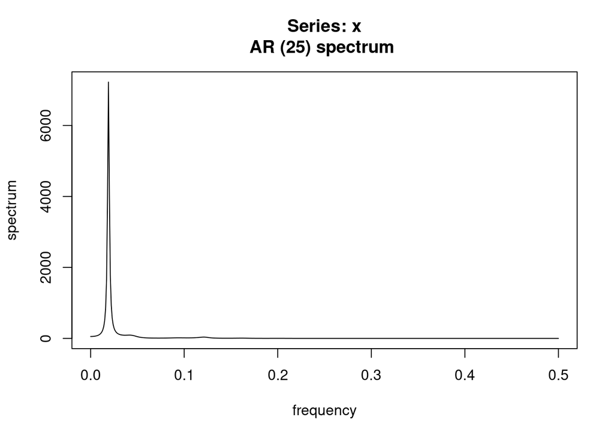

```r
freq <- specvalues$freq[which.max(specvalues$spec)]
freq
```

```
## [1] 0.01903808
```

The `spec.ar` function converged to an **AR(25)** model with a discovered frequency of 0.0190381

Based on the results of the periodograms, the period appears to be 50